# Reproducible Research: Peer Assessment 1

## Loading and preprocessing the data

1) Load the data into R as a data frame and look at it.

```r
activity = read.csv("activity.csv")
str(activity)
```

```
## 'data.frame':    17568 obs. of  3 variables:
##  $ steps   : int  NA NA NA NA NA NA NA NA NA NA ...
##  $ date    : Factor w/ 61 levels "2012-10-01","2012-10-02",..: 1 1 1 1 1 1 1 1 1 1 ...
##  $ interval: int  0 5 10 15 20 25 30 35 40 45 ...
```

2) Let's convert the date variable from a factor to a date.

```r
activity$date <- as.Date(activity$date)
str(activity)
```

```
## 'data.frame':    17568 obs. of  3 variables:
##  $ steps   : int  NA NA NA NA NA NA NA NA NA NA ...
##  $ date    : Date, format: "2012-10-01" "2012-10-01" ...
##  $ interval: int  0 5 10 15 20 25 30 35 40 45 ...
```

```r
summary(activity)
```

```
##      steps            date               interval
##  Min.   :  0.0   Min.   :2012-10-01   Min.   :   0
##  1st Qu.:  0.0   1st Qu.:2012-10-16   1st Qu.: 589
##  Median :  0.0   Median :2012-10-31   Median :1178
##  Mean   : 37.4   Mean   :2012-10-31   Mean   :1178
##  3rd Qu.: 12.0   3rd Qu.:2012-11-15   3rd Qu.:1766
##  Max.   :806.0   Max.   :2012-11-30   Max.   :2355
##  NA's   :2304
```

Make a new data frame for total daily steps.

```r
library(plyr)
dailysteps <- ddply(activity, .(date), summarise, totalsteps = sum(steps))
str(dailysteps)
```

```
## 'data.frame':    61 obs. of  2 variables:
##  $ date      : Date, format: "2012-10-01" "2012-10-02" ...
##  $ totalsteps: int  NA 126 11352 12116 13294 15420 11015 NA 12811 9900 ...
```

```r
summary(dailysteps)
```

```
##       date              totalsteps
##  Min.   :2012-10-01   Min.   :   41
##  1st Qu.:2012-10-16   1st Qu.: 8841
##  Median :2012-10-31   Median :10765
##  Mean   :2012-10-31   Mean   :10766
##  3rd Qu.:2012-11-15   3rd Qu.:13294
##  Max.   :2012-11-30   Max.   :21194
##                       NA's   :8
```

## What is mean total number of steps taken per day?

1) Make a histogram of the total number of steps taken each day.

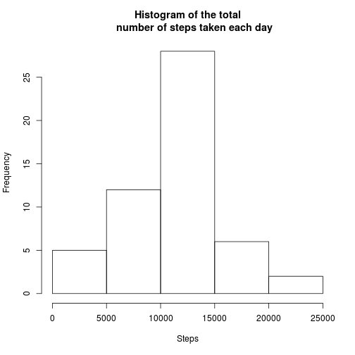

```r
hist(dailysteps$totalsteps, main = "Histogram of the total\n     number of steps taken each day",
    xlab = "Steps")
```

2) Calculate the mean and median total steps per day.

```r
mean(dailysteps$totalsteps, na.rm = T)
```

```
## [1] 10766
```

```r
median(dailysteps$totalsteps, na.rm = T)
```

```
## [1] 10765
```

The mean number of daily steps is 10766, and the median number of daily steps is 10765.

## What is the average daily activity pattern?

Let's manipulate the activity data frame so that it is easier to work with.

```r
dailyactivity <- ddply(activity, .(interval), summarise, avesteps = mean(steps,
    na.rm = T))
str(dailyactivity)
```

```
## 'data.frame':    288 obs. of  2 variables:
##  $ interval: int  0 5 10 15 20 25 30 35 40 45 ...
##  $ avesteps: num  1.717 0.3396 0.1321 0.1509 0.0755 ...
```

```r
summary(dailyactivity)
```

```
##     interval       avesteps
##  Min.   :   0   Min.   :  0.00
##  1st Qu.: 589   1st Qu.:  2.49
##  Median :1178   Median : 34.11
##  Mean   :1178   Mean   : 37.38
##  3rd Qu.:1766   3rd Qu.: 52.83
##  Max.   :2355   Max.   :206.17
```

1) Make a time series plot of the 5-minute interval (x-axis) and the average number of steps taken, averaged across all days (y-axis).

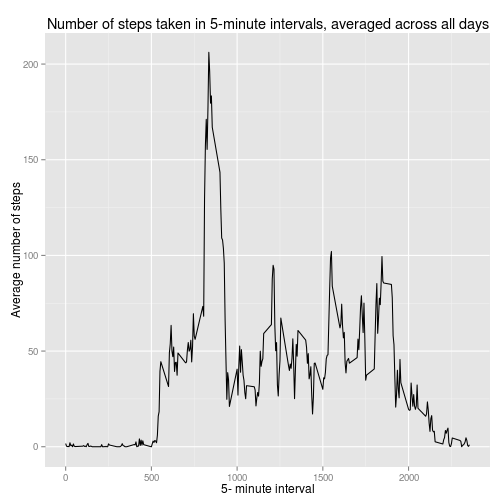

```r
library(ggplot2)
myplot <- ggplot(dailyactivity, aes(x = interval, y = avesteps))
myplot <- myplot + geom_line()
myplot <- myplot + labs(x = "5- minute interval", y = "Average number of steps",
    title = "Number of steps taken in 5-minute intervals, averaged across all days")
myplot
```

2) Determine which 5-minute interval contains the maximum number of steps.

```r
maxsteps <- which.max(dailyactivity$avesteps)
dailyactivity$avesteps[maxsteps]
```

```
## [1] 206.2
```

```r
dailyactivity$interval[maxsteps]
```

```
## [1] 835
```

The interval number 835 contains the maximum number of steps. That looks consistent with our plot.

## Imputing missing values

1) Find the total number of missing values in the dataset.

```r
summary(activity)
```

```
##      steps            date               interval
##  Min.   :  0.0   Min.   :2012-10-01   Min.   :   0
##  1st Qu.:  0.0   1st Qu.:2012-10-16   1st Qu.: 589
##  Median :  0.0   Median :2012-10-31   Median :1178
##  Mean   : 37.4   Mean   :2012-10-31   Mean   :1178
##  3rd Qu.: 12.0   3rd Qu.:2012-11-15   3rd Qu.:1766
##  Max.   :806.0   Max.   :2012-11-30   Max.   :2355
##  NA's   :2304
```

The steps variable is the only variable with missing values. There are 2304 missing values in the dataset.

2) Devise a strategy to replace missing values. I will replace the missing values with the average for that interval, since the pattern varies significantly over the course of a day. First I will merge the daily pattern data frame with the activity data frame.

```r
activity2 <- merge(activity, dailyactivity)
str(activity2)
```

```
## 'data.frame':    17568 obs. of  4 variables:
##  $ interval: int  0 0 0 0 0 0 0 0 0 0 ...
##  $ steps   : int  NA 0 0 0 0 0 0 0 0 0 ...
##  $ date    : Date, format: "2012-10-01" "2012-11-23" ...
##  $ avesteps: num  1.72 1.72 1.72 1.72 1.72 ...
```

```r
summary(activity2)
```

```
##     interval        steps            date               avesteps
##  Min.   :   0   Min.   :  0.0   Min.   :2012-10-01   Min.   :  0.00
##  1st Qu.: 589   1st Qu.:  0.0   1st Qu.:2012-10-16   1st Qu.:  2.49
##  Median :1178   Median :  0.0   Median :2012-10-31   Median : 34.11
##  Mean   :1178   Mean   : 37.4   Mean   :2012-10-31   Mean   : 37.38
##  3rd Qu.:1766   3rd Qu.: 12.0   3rd Qu.:2012-11-15   3rd Qu.: 52.83
##  Max.   :2355   Max.   :806.0   Max.   :2012-11-30   Max.   :206.17
##                 NA's   :2304
```

3) Now create a new dataset equal to the original but with the missing data filled in.

```r
activity2$steps[is.na(activity2$steps)] <- activity2$avesteps
activity2$avesteps <- NULL
str(activity2)
```

```
## 'data.frame':    17568 obs. of  3 variables:
##  $ interval: int  0 0 0 0 0 0 0 0 0 0 ...
##  $ steps   : num  1.72 0 0 0 0 ...
##  $ date    : Date, format: "2012-10-01" "2012-11-23" ...
```

```r
summary(activity2)
```

```
##     interval        steps            date
##  Min.   :   0   Min.   :  0.0   Min.   :2012-10-01
##  1st Qu.: 589   1st Qu.:  0.0   1st Qu.:2012-10-16
##  Median :1178   Median :  0.0   Median :2012-10-31
##  Mean   :1178   Mean   : 32.5   Mean   :2012-10-31
##  3rd Qu.:1766   3rd Qu.:  1.7   3rd Qu.:2012-11-15
##  Max.   :2355   Max.   :806.0   Max.   :2012-11-30
```

4) Make a histogram of the total number of steps taken each day and calculate the mean and median total number of steps taken per day. First I will make a new data frame for the total daily steps.

```r
dailysteps2 <- ddply(activity2, .(date), summarise, totalsteps = sum(steps))
str(dailysteps2)
```

```
## 'data.frame':    61 obs. of  2 variables:
##  $ date      : Date, format: "2012-10-01" "2012-10-02" ...
##  $ totalsteps: num  129 126 11352 12116 13294 ...
```

```r
summary(dailysteps2)
```

```
##       date              totalsteps
##  Min.   :2012-10-01   Min.   :   41
##  1st Qu.:2012-10-16   1st Qu.: 6778
##  Median :2012-10-31   Median :10395
##  Mean   :2012-10-31   Mean   : 9371
##  3rd Qu.:2012-11-15   3rd Qu.:12811
##  Max.   :2012-11-30   Max.   :21194
```

Now make the histogram.

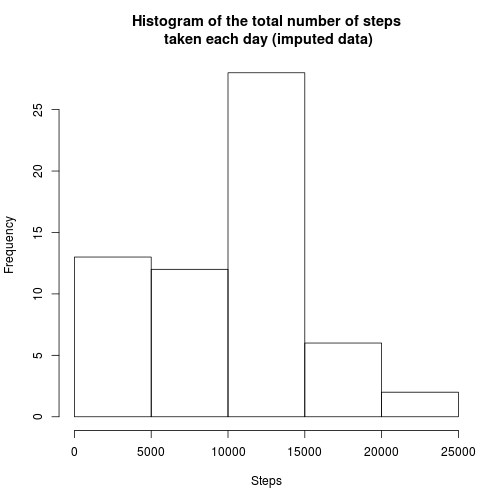

```r
hist(dailysteps2$totalsteps, main = "Histogram of the total number of steps\n taken each day (imputed data)",
    xlab = "Steps")
```

```r
mean(dailysteps2$totalsteps)
```

```
## [1] 9371
```

```r
median(dailysteps2$totalsteps)
```

```
## [1] 10395
```

Now the mean and median total steps are 9371 and 10395, respectively. Imputing missing data has changed these estimates, and in this case, lowers both the mean and median, with a more significant effect on the mean.

## Are there differences in activity patterns between weekdays and weekends?

1) Create a new factor variable in the dataset with two levels “weekday” and “weekend.”

```r
activity2$dayofweek <- weekdays(activity2$date)
head(activity2)
```

```
##   interval steps       date dayofweek
## 1        0 1.717 2012-10-01    Monday
## 2        0 0.000 2012-11-23    Friday
## 3        0 0.000 2012-10-28    Sunday
## 4        0 0.000 2012-11-06   Tuesday
## 5        0 0.000 2012-11-24  Saturday
## 6        0 0.000 2012-11-15  Thursday
```

```r
activity2$dayofweek[activity2$dayofweek == "Saturday" | activity2$dayofweek ==
    "Sunday"] <- "weekend"
activity2$dayofweek[activity2$dayofweek != "weekend"] <- "weekday"
activity2$dayofweek <- as.factor(activity2$dayofweek)
head(activity2)
```

```
##   interval steps       date dayofweek
## 1        0 1.717 2012-10-01   weekday
## 2        0 0.000 2012-11-23   weekday
## 3        0 0.000 2012-10-28   weekend
## 4        0 0.000 2012-11-06   weekday
## 5        0 0.000 2012-11-24   weekend
## 6        0 0.000 2012-11-15   weekday
```

```r
str(activity2)
```

```
## 'data.frame':    17568 obs. of  4 variables:
##  $ interval : int  0 0 0 0 0 0 0 0 0 0 ...
##  $ steps    : num  1.72 0 0 0 0 ...
##  $ date     : Date, format: "2012-10-01" "2012-11-23" ...
##  $ dayofweek: Factor w/ 2 levels "weekday","weekend": 1 1 2 1 2 1 2 1 1 2 ...
```

2) Make a panel plot containing a time series plot of the 5-minute interval (x-axis) and the average number of steps taken, averaged across all weekday days or weekend days (y-axis).

```r
activity3 <- ddply(activity2, .(interval, dayofweek), summarise, avesteps = mean(steps))
summary(activity3)
```

```
##     interval      dayofweek      avesteps
##  Min.   :   0   weekday:288   Min.   :  0.00
##  1st Qu.: 589   weekend:288   1st Qu.:  1.64
##  Median :1178                 Median : 22.85
##  Mean   :1178                 Mean   : 34.22
##  3rd Qu.:1766                 3rd Qu.: 54.56
##  Max.   :2355                 Max.   :202.98
```

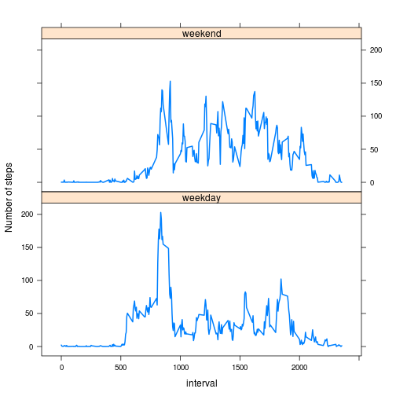

```r
library(lattice)
xyplot(avesteps ~ interval | dayofweek, data = activity3, type = "l", lwd = 2,
    layout = c(1, 2), ylab = "Number of steps")
```